# 2020_02_Kuggle_정규세션_W1_09.08

## 2.1 설명

- EDA(Exploratory Data Analysis/탐색적자료분석):  
  수집한 데이터가 들어왔을 때, 이를 다양한 각도에서 관찰하고 이해하며 자료를 직관적으로 바라보는 과정

```
- Matplotlib
- Seaborn

- 수치형변수 & 명목형변수의 관계파악
```

[figure not shown]

### 2.1.1 Matplotlib

```python
import matplotlib.pyplot as plt
```

```python
#데이터 불러오기
titanic = pd.read_csv("titanic.csv")
titanic.info()
titanic
```

```
<class 'pandas.core.frame.DataFrame'>
RangeIndex: 891 entries, 0 to 890
Data columns (total 12 columns):
PassengerId    891 non-null int64
Survived       891 non-null int64
Pclass         891 non-null int64
Name           891 non-null object
Sex            891 non-null object
Age            891 non-null float64
SibSp          891 non-null int64
Parch          891 non-null int64
Ticket         891 non-null object
Fare           891 non-null float64
Cabin          204 non-null object
Embarked       889 non-null object
dtypes: float64(2), int64(5), object(5)
memory usage: 83.7+ KB
```

|  | PassengerId | Survived | Pclass | Name | Sex | Age | SibSp | Parch | Ticket | Fare | Cabin | Embarked |
| --- | --- | --- | --- | --- | --- | --- | --- | --- | --- | --- | --- | --- |
| 0 | 1 | 0 | 3 | Braund, Mr. Owen Harris | male | 22.0 | 1 | 0 | A/5 21171 | 7.2500 | NaN | S |
| 1 | 2 | 1 | 1 | Cumings, Mrs. John Bradley (Florence Briggs Th... | female | 38.0 | 1 | 0 | PC 17599 | 71.2833 | C85 | C |
| 2 | 3 | 1 | 3 | Heikkinen, Miss. Laina | female | 26.0 | 0 | 0 | STON/O2. 3101282 | 7.9250 | NaN | S |
| 3 | 4 | 1 | 1 | Futrelle, Mrs. Jacques Heath (Lily May Peel) | female | 35.0 | 1 | 0 | 113803 | 53.1000 | C123 | S |
| 4 | 5 | 0 | 3 | Allen, Mr. William Henry | male | 35.0 | 0 | 0 | 373450 | 8.0500 | NaN | S |
| ... | ... | ... | ... | ... | ... | ... | ... | ... | ... | ... | ... | ... |
| 886 | 887 | 0 | 2 | Montvila, Rev. Juozas | male | 27.0 | 0 | 0 | 211536 | 13.0000 | NaN | S |
| 887 | 888 | 1 | 1 | Graham, Miss. Margaret Edith | female | 19.0 | 0 | 0 | 112053 | 30.0000 | B42 | S |
| 888 | 889 | 0 | 3 | Johnston, Miss. Catherine Helen "Carrie" | female | 30.0 | 1 | 2 | W./C. 6607 | 23.4500 | NaN | S |
| 889 | 890 | 1 | 1 | Behr, Mr. Karl Howell | male | 26.0 | 0 | 0 | 111369 | 30.0000 | C148 | C |
| 890 | 891 | 0 | 3 | Dooley, Mr. Patrick | male | 32.0 | 0 | 0 | 370376 | 7.7500 | NaN | Q |

891 rows × 12 columns

```python
#명목형변수 설정
titanic['Survived'] = titanic['Survived'].astype(object)
titanic['Pclass'] = titanic['Pclass'].astype(object)
titanic.info()
```

```
<class 'pandas.core.frame.DataFrame'>
RangeIndex: 891 entries, 0 to 890
Data columns (total 12 columns):
PassengerId    891 non-null int64
Survived       891 non-null object
Pclass         891 non-null object
Name           891 non-null object
Sex            891 non-null object
Age            891 non-null float64
SibSp          891 non-null int64
Parch          891 non-null int64
Ticket         891 non-null object
Fare           891 non-null float64
Cabin          204 non-null object
Embarked       889 non-null object
dtypes: float64(2), int64(3), object(7)
memory usage: 83.7+ KB
```

> 1.종속변수의 탐색

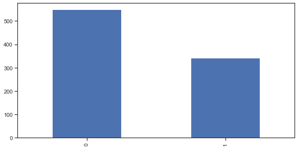

```python
titanic['Survived'].value_counts().plot(kind='bar',figsize=(10,5))
plt.show()
```

> 2.명목형변수의 탐색
- 1) 다변수의 탐색

```python
#object 타입을 가진 컬럼만 뽑아서 명목형 변수의 리스트
category_feature = [ col for col in titanic.columns if titanic[col].dtypes == "object"]
category_feature
```

```
['Survived', 'Pclass', 'Name', 'Sex', 'Ticket', 'Cabin', 'Embarked']
```

```python
# 데이터의 기본키(인덱스), 종속변수 등을 제외하고 분석
category_feature = list(set(category_feature) - set(['PassengerId','Survived']))
category_feature
```

```
['Embarked', 'Pclass', 'Sex', 'Cabin', 'Name', 'Ticket']
```

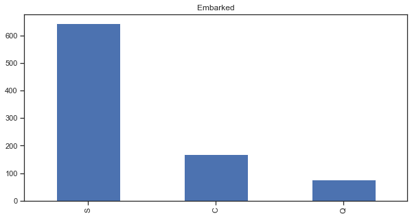

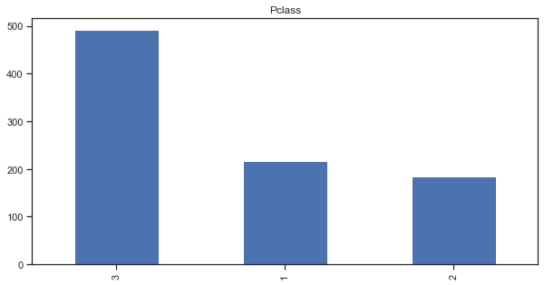

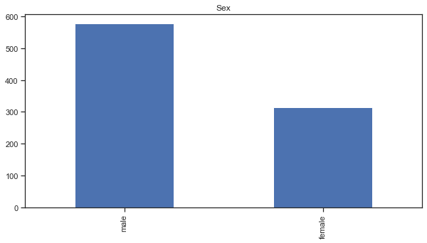

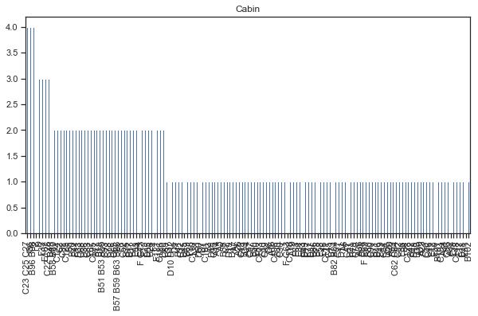

[figure not shown]

[figure not shown]

```python
for col in category_feature:
    titanic[col].value_counts().plot(kind='bar',figsize=(10,5))
    plt.title(col)
    plt.show()

# 명목형 변수를 어떻게 다룰지를 판단
# 카테고리수가 너무 많고, 종속변수와 별로 관련이 없어보이는 독립 변수들은 빼고 분석
```

- 2) 이변수의 탐색

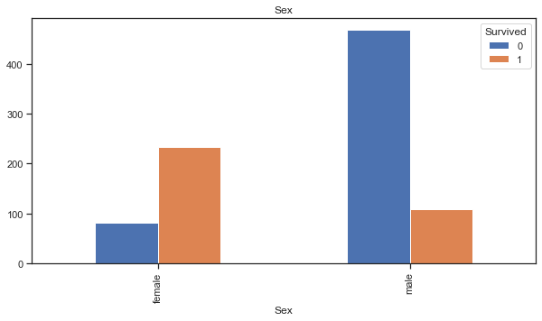

```python
sex_df = titanic.groupby(['Sex','Survived'])['Survived'].count().unstack('Survived')
sex_df.plot(kind='bar', figsize=(10,5))
plt.title('Sex')
plt.show()
```

### 2.1.2 Seaborn

```python
import seaborn as sns
```

> 1.수치형변수 탐색
- 1) 단변수 탐색  
  seaborn 패키지의 distplot

```python
#범주형 변수와 기타 인덱스 변수, 종속변수들을 제외하고 수치형 변수만을 가진 리스트 생성
numerical_feature = list(set(titanic.columns) - set(category_feature) - set(['PassengerId','Survived']))
numerical_feature = np.sort(numerical_feature)
numerical_feature
```

```
array(['Age', 'Fare', 'Parch', 'SibSp'], dtype='<U5')
```

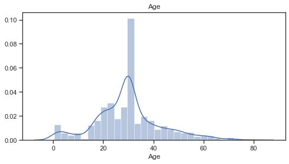

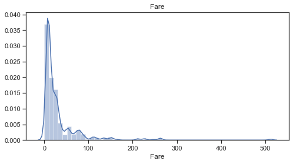

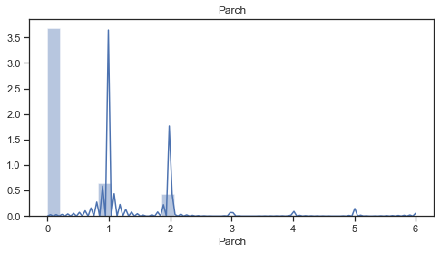

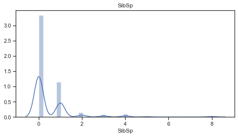

```python
for col in numerical_feature:
    sns.distplot(titanic.loc[titanic[col].notnull(), col])
    plt.title(col)
    plt.show()
```

- 2) 이변수, 삼변수 탐색  
  seaborn의 pairplot

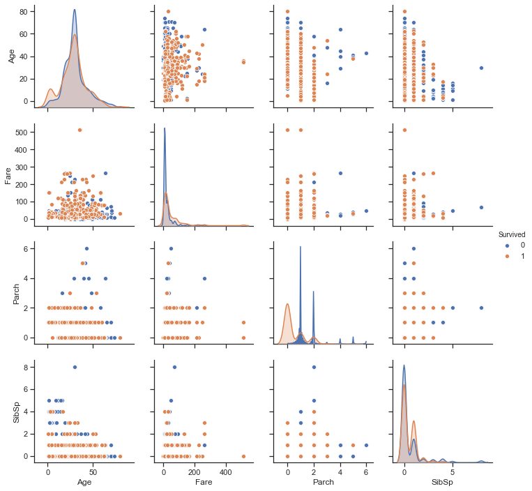

```python
sns.pairplot(titanic[list(numerical_feature) + ['Survived']], hue='Survived',
             x_vars=numerical_feature, y_vars=numerical_feature)
plt.show()

#pairplot은 여러 변수의 관계를 한 번에 파악할 수 있음
#hue 파라미터를 통해 종속변수를 지정함으로써 세 변수의 관계를 파악
```

### 2.1.3 수치형변수&명목형변수의 관계파악

성별, 나이, 생존여부 3개의 변수(수치&명목) 를 동시에 탐색하고 싶을 수 있음  
이 경우에 명목형 변수에 따라 수치형변수의 boxplot을 그려봄으로써 대략적인 데이터의 형태를 살펴볼 수 있음

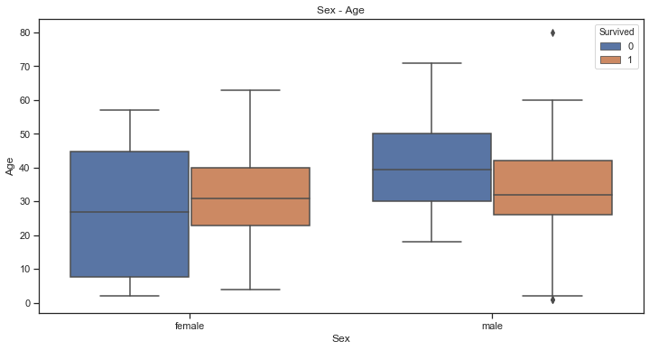

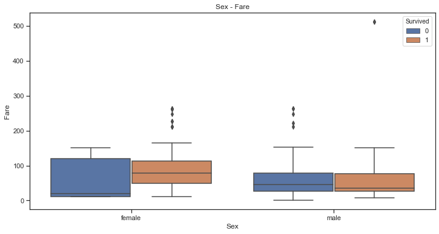

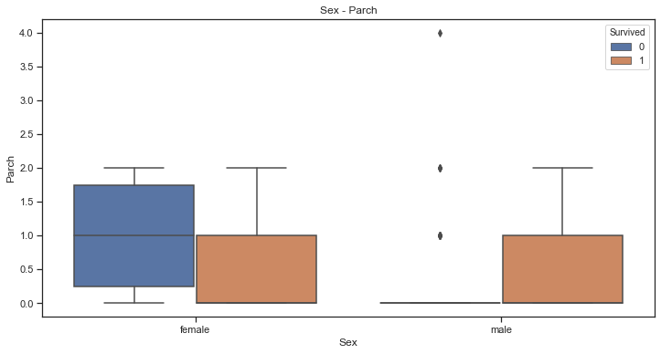

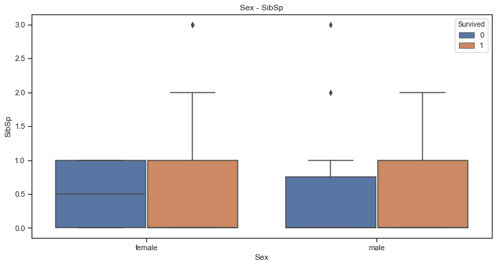

```python
unique_list = titanic['Sex'].unique()

for col in numerical_feature:
    plt.figure(figsize=(12,6))
    sns.boxplot(x='Sex', y=col, hue='Survived', data=titanic.dropna())
    plt.title("Sex - {}".format(col))
    plt.show()
```

## 2.2 쥬피터 실습

[figure not shown]

```python
# 1.‘test2’변수명을 가진 데이터 프레임으로 data2.csv 파일 불러오기
```

```python
# 2.종속변수인 ‘pass’칼럼의 vlaue를 나타내는 그래프 출력 (변수명:pass_df)
```

```python
# 3.‘sex’별 ‘pass’를 나타내는 그래프 출력 (변수명: sex_df)
```

```python
# 4.‘average’의 수치형 분포를 나타내는 그래프 출력 (변수명: average_df)
```

##### ===============================================================================================================

# 3. Class ( 클래스 )

[figure not shown]

## 3.1 설명

- Class(클래스): 클래스는 객체를 표현하기 위한 문법

```
- 클래스는 객체의 구조와 행동을 정의함
- 객체의 클래스는 초기화를 통해 제어함
- 클래스는 복잡한 문제를 다루기 쉽도록함
```

[figure not shown]

- ex) 계산기 > 더하기 빼기, 나누기, 곱하기 등등
- ex) 바람의 나라~^^ㅋㅋ 직업선택! > 기사, 마법사, 궁수, 사제 등 직업별로 클래스를 만들어서 표현

'클래스'는 우리의 영원한 파이썬 교과서 '점투파'를 중심으로..ㅎ^^ 설명~~

### 3.1.1 클래스와 객체 / 클래스의 구성

[figure not shown]

```python
#클래스 생성
class Cookie:
    pass
```

```python
#a와 b가 객체 (a는 Cookie의 인스턴스)
a = Cookie()
b = Cookie()
```

```python
#클래스 생성
class Calculator:
    def __init__(self):
        self.result = 0

    def add(self, num):
        self.result += num
        return self.result
```

```python
#cal1,cal2가 객체 (그리고 각각의 결괏값 역시 다른 계산기의 결괏값과 상관없이 독립적인 값을 유지)
cal1 = Calculator()
cal2 = Calculator()

print(cal1.add(3))
print(cal1.add(4))

print(cal2.add(3))
print(cal2.add(7))
```

```
3
7
3
10
```

### 3.1.2 클래스 구조 만들기

> 일반적으로 함수를 만드는 과정

```
def 함수명(매개변수):
    수행할 문장
    ...
```

```python
class FourCal:
    def setdata(self, first, second):
        self.first = first
        self.second = second
```

```python
class FourCal:
    def setdata(self, first, second):  # 메서드의 매개변수 (관례적으로 self를 사용, 객체를 호출할 때 자신이 전달되기 때문)
        self.first = first             # 메서드의 수행문
        self.second = second           # 메서드의 수행문
```

```python
a = FourCal()
a.setdata(4, 2) # a객체를 통해 setdata 메서드를 호출
```

[figure not shown]

```
self.first = 4
self.second = 2

a.first = 4
a.second = 2
```

```python
a = FourCal()
a.setdata(4, 2)

print(a.first)
print(a.second)
```

```
4
2
```

```python
#2개의 객체 생성 > 서로 독립적으로 작용
a = FourCal()
b = FourCal()
```

```python
a.setdata(4, 2)
print(a.first)
```

```
4
```

```python
b.setdata(3, 7)
print(b.first)
```

```
3
```

```python
#전체 계산기 Class (더하기,빼기,곱하기,나누기)
class FourCal:
    def setdata(self, first, second):
        self.first = first
        self.second = second

    def add(self):
        result = self.first + self.second
        return result

    def mul(self):
        result = self.first * self.second
        return result

    def sub(self):
        result = self.first - self.second
        return result

    def div(self):
        result = self.first / self.second
        return result
```

```python
a = FourCal()
b = FourCal()

a.setdata(4, 2)
b.setdata(3, 8)

print(a.add())
print(a.mul())
print(a.sub())
print(a.div())

print(b.add())
print(b.mul())
print(b.sub())
print(b.div())
```

```
6
8
2
2.0
11
24
-5
0.375
```

### 3.1.3 생성자 (Constructor)

```python
a = FourCal()
a.add()

#setdata 메서드를 수행해야 객체 a의 객체변수 first와 second가 생성되기 때문
```

```
---------------------------------------------------------------------------
AttributeError                            Traceback (most recent call last)
<ipython-input-385-c6e193a8566b> in <module>
      1 a = FourCal()
----> 2 a.add()
      3
      4 #setdata 메서드를 수행해야 객체 a의 객체변수 first와 second가 생성되기 때문

<ipython-input-380-a4051b93bd15> in add(self)
      6
      7     def add(self):
----> 8         result = self.first + self.second
      9         return result
     10

AttributeError: 'FourCal' object has no attribute 'first'
```

```
class FourCal:
    def setdata(self, first, second):
        self.first = first
        self.second = second

    def add(self):
        result = self.first + self.second
        return result

    def mul(self):
        result = self.first * self.second
        return result

    def sub(self):
        result = self.first - self.second
        return result

    def div(self):
        result = self.first / self.second
        return result
```

> 객체에 초깃값을 설정해야 할 필요가 있을 때는 setdata와 같은 메서드보다 생성자를 구현하는 것이 안전한 방법
> - 파이썬 메서드 이름으로 **init**를 사용하면 이 메서드는 생성자

```python
class FourCal:
    def __init__(self, first, second): #생성자로 인식되어 객체가 생성되는 시점에 자동으로 호출됨 / (initializer)의 약자
        self.first = first
        self.second = second

    def setdata(self, first, second):
        self.first = first
        self.second = second

    def add(self):
        result = self.first + self.second
        return result

    def mul(self):
        result = self.first * self.second
        return result

    def sub(self):
        result = self.first - self.second
        return result

    def div(self):
        result = self.first / self.second
        return result
```

```python
a = FourCal()
```

```
---------------------------------------------------------------------------
TypeError                                 Traceback (most recent call last)
<ipython-input-439-5cfa1e393ba9> in <module>
----> 1 a = FourCal()

TypeError: __init__() missing 2 required positional arguments: 'first' and 'second'
```

```python
a = FourCal(4, 2)
print(a.first)
print(a.second)
```

```
4
2
```

### 3.1.4 클래스의 상속

- 클래스의 상속: 어떤 클래스를 만들 때 다른 클래스의 기능을 물려받을 수 있게 만드는 것

```python
class MoreFourCal(FourCal): #새로운 class 클래스 이름(상속할 클래스 이름)
    pass
```

```python
#상속되었는지 확인
a = MoreFourCal(4, 2)

print(a.add())
print(a.mul())
print(a.sub())
print(a.div())
```

```
6
8
2
2.0
```

```python
#fourCal 클래스에 a**b (a의 b제곱)을 구할 수 있는 기능을 추가

class MoreFourCal(FourCal):
    def pow(self):
        result = self.first ** self.second
        return result
```

```python
a = MoreFourCal(4, 2) #'__init__'도 잘들어감
a.pow()
```

```
16
```

### 3.1.5 매서드 오버라이팅

```python
a = FourCal(4, 0)
a.div()
```

```
---------------------------------------------------------------------------
ZeroDivisionError                         Traceback (most recent call last)
<ipython-input-407-5e9b2f546e11> in <module>
      1 a = FourCal(4, 0)
----> 2 a.div()

<ipython-input-391-68ce298afd5c> in div(self)
     21
     22     def div(self):
---> 23         result = self.first / self.second
     24         return result

ZeroDivisionError: division by zero
```

```python
class SafeFourCal(FourCal): #클래스 상속
    def div(self): #원래 함수의 이름
        if self.second == 0:  # 나누는 값이 0인 경우 0을 리턴하도록 수정
            return 0
        else:
            return self.first / self.second
```

```python
a = SafeFourCal(4, 0)
a.div()
```

```
0
```

### 3.1.6 클래스 변수 ( vs 객체변수)

```python
class Family:
    lastname = "김" #클래스 변수
```

```python
print(Family.lastname)
```

```
김
```

```python
a = Family() #객체1
b = Family() #객체2

print(a.lastname)
print(b.lastname)
```

```
김
김
```

```python
#Family 클래스의 lastname을 "박"이라는 문자열로 변경
Family.lastname = "박"
```

```python
print(a.lastname)
print(b.lastname)
```

```
박
박
```

- 클래스 변수 값을 변경했더니 클래스로 만든 객체의 lastname 값도 모두 변경된다는 것을 확인할 수 있음
- 클래스 변수는 클래스로 만든 모든 객체에 공유됨 (vs 객체변수는 서로 독립적이다)

```python
print(id(Family.lastname))

print(id(a.lastname))

print(id(b.lastname))
```

```
140511167710992
140511167710992
140511167710992
```

```python
print(id(a))
print(id(b))
```

```
140511178454800
140511178454736
```

## 3.2 쥬피터 실습

[figure not shown]

```python
#시간제한타이머
from countdown import countdown

countdown(5)
```

```python
# 1. 'Figure'변수명을 가진 Class 만들기
Class:

    # 2. 생성자(initializer)로 width와 height을 받을 수 있게 함수 생성
    def

    # 3. 'is_square'이름의 함수 만들기
    def
```

##### ===============================================================================================================

### 마무리를 하며...

- 10주에 거쳐서 많은 양의 진도로 나가기 때문에 한주라도 놓치면 많은 양을 놓침 > 집중!!! but 그만큼 잘해놓으면은 좋겠쥬?!
- 커리로 짜여진 범위 자체가 어려움 > 나만 어려운게 아니라 모두가 어려워하고 있으니까 걱정 ㄴㄴ
- 공부가 지겹고 힘들땐 프로젝트를 해보거나 실데이터를 다루는것 추천!
- 눈으로 보는 거랑 다르기 때문에 꼭꼭꼭 문제를 풀어보셔야 합니다!! > 레에에에알임

[figure not shown]